# Arkesh Das CMSE 410 Semester Project

Arkesh Das

03/30/2025

# Assessing the Influence of False Discovery Rate Methods on Genetic Associations in an Immune Response GWAS

## Background

Genome-wide association studies (GWAS) have emerged as powerful tools for linking genetic variants with complex traits, including immune responses. A typical GWAS involves testing millions of single nucleotide polymorphisms (SNPs) for associations, which leads to a substantial multiple testing burden. Applying a simple p-value threshold (e.g., 0.05) is inadequate, as it would generate many false positives. Thus, false discovery rate (FDR) control has become an essential strategy to address this challenge.

## About the data

This project utilizes data from the Milieu Intérieur (MI) project, a comprehensive, population-based study coordinated by Prof. Lluis Quintana-Murci and Dr. Darragh Duffy at Institut Pasteur in Paris. Established under the French Government’s Investissement d’Avenir – Laboratoire d’Excellence (LabEx) initiative, the MI project aims to dissect the interplay between genetics, environment, and immune variation [1].

It was designed to address a critical discrepancy in medicine: while immune responses vary widely among individuals, medical care and therapeutic strategies are often standardized across populations.

I chose to use this dataset because it offers a unique opportunity to evaluate the impact of false discovery rate methods on GWAS results in the context of immune variation, and the data is high-resolution and well-characterized so it’s ideal for benchmarking statistical methods.

The data was accessed from the NHGRI-EBI GWAS Catalog. The Catalog is a publicly available repository of SNP-trait associations identified in published GWAS studies. It provides standardized annotations, p-values, effect sizes, and sample information for millions of SNPs across hundreds of phenotypes.

The MI cohort consists of 1,000 healthy individuals, age- and sex-stratified across five decades (ages 20-70), and of French origin. Detailed serological data were collected, including total levels of IgA, IgE, IgG, and IgM, along with antibody responses to 15 antigens from common infectious agents and vaccines (e.g., influenza, EBV, CMV, HSV, rubella). The cohort was genotyped for over 700,000 SNPs and subsequently imputed to yield over 12 million genetic variants. Extensive phenotypic, demographic, clinical, and environmental metadata are also available, including vaccine history, infection exposure, CRP levels, lipid profiles, and lifestyle factors [2].

# Reading in the Data and making dataframes

# Creating Manhattan Plots

Because I will be making several Manhattan, QQ, and adjusted p-value plots, I created reusable plotting functions. This keeps the visual style consistent and makes it easier to compare results across FDR methods.

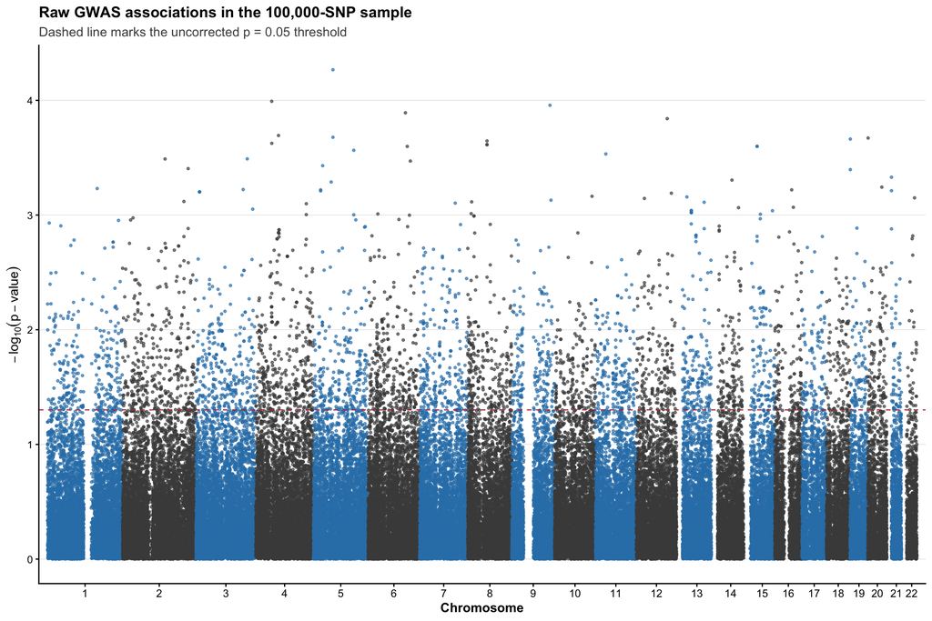

The first plot uses the raw p-values from the 100,000-SNP sample and overlays a Bonferroni threshold. This is a useful baseline because it shows how stringent family-wise error control becomes in a GWAS setting.

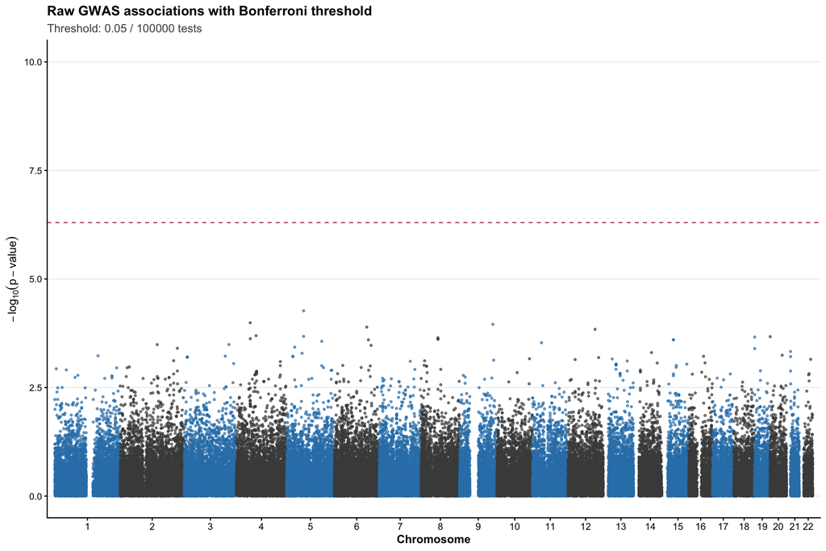

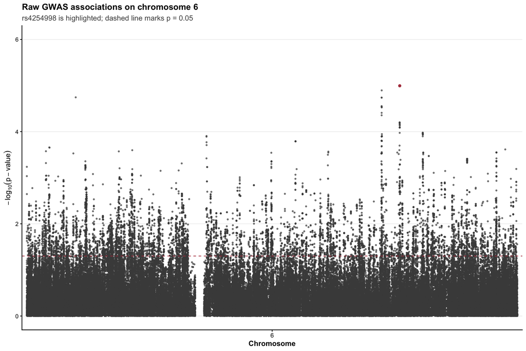

# QQ plots

QQ plots are useful here because they compare the observed p-value distribution with what would be expected under the global null hypothesis. Large departures from the diagonal can indicate true association signal, inflation, or population structure that still needs to be checked.

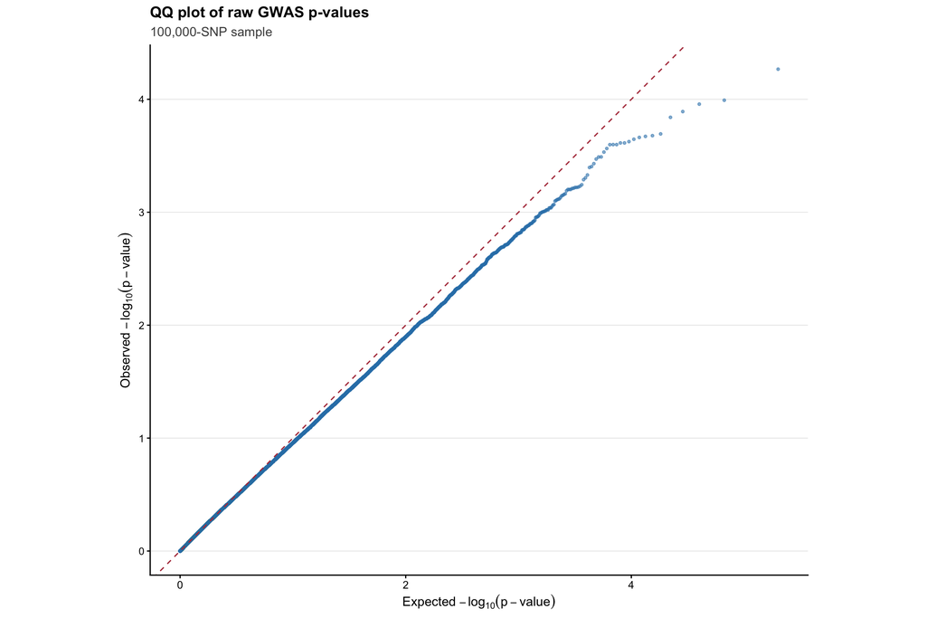

[figure not shown]

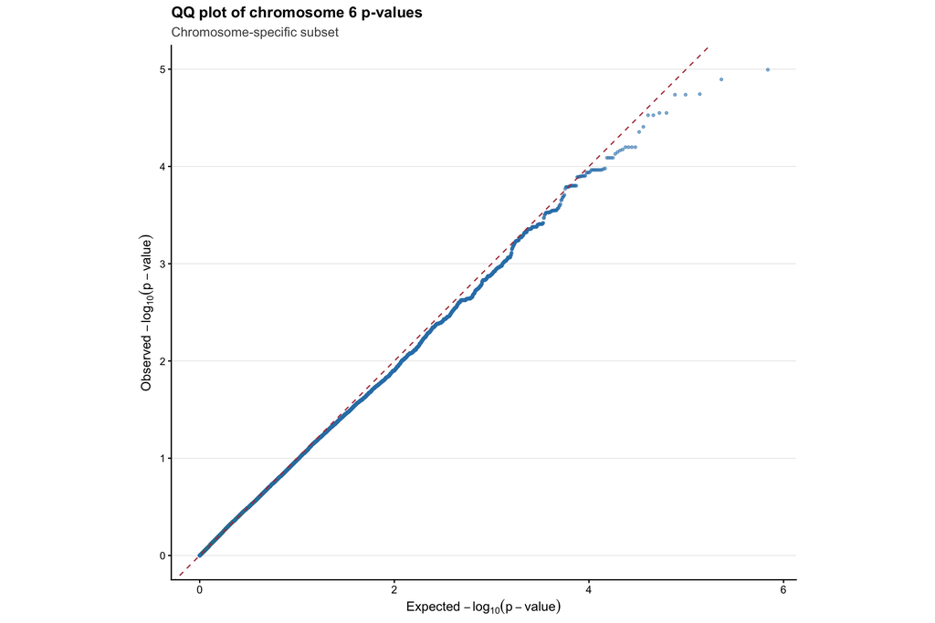

# Various FDR methods

Now I will be trying different FDR methods, from most to least conservative.

## Benjamini-Yekutieli

Out of the p-value adjustment methods, Benjamini Yekuteli is the most conservative, so I will try it first. R has a `p.adjust` function that can automatically apply the BY method.

```
##    Min. 1st Qu.  Median    Mean 3rd Qu.    Max.
##       1       1       1       1       1       1
```

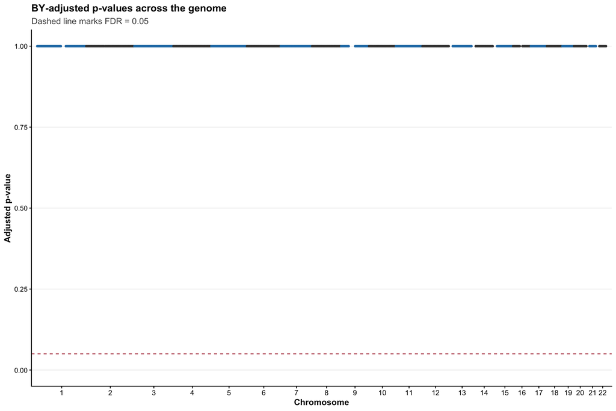

Because BY-adjusted p-values are adjusted significance values rather than raw association p-values, I plot them on the adjusted p-value scale instead of forcing them into a standard Manhattan plot.

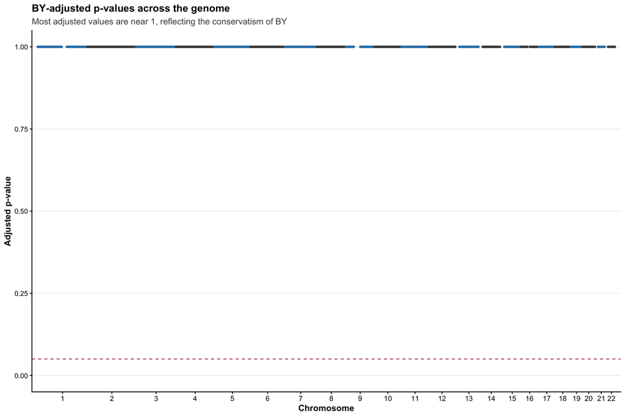

Using this adjusted p-value plot, we can see that the Benjamini-Yekutieli method is highly conservative for this dataset. In the 100,000-SNP sample, it does not identify any variants below an FDR threshold of 0.05.

## Benjamini-Hochberg

Now I will try adjust my p-values using the Benjamini-Hochberg method.

```
##    Min. 1st Qu.  Median    Mean 3rd Qu.    Max.
##  0.9949  0.9949  0.9949  0.9957  0.9964  1.0000
```

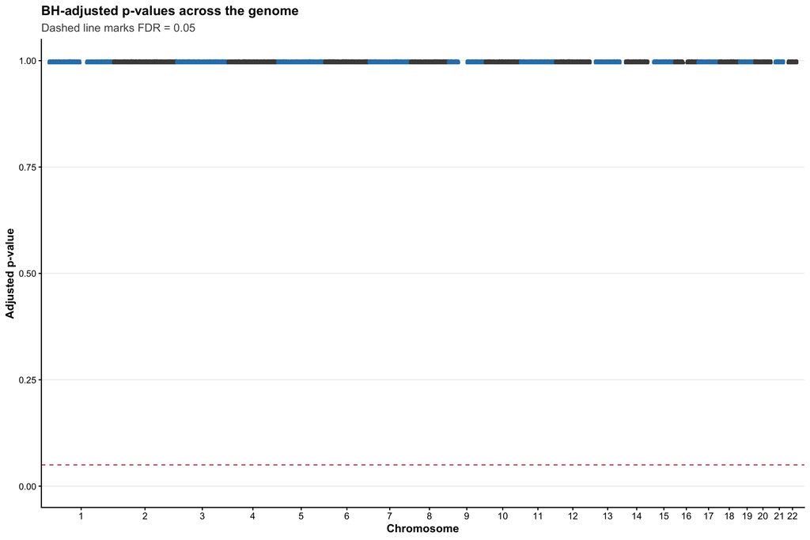

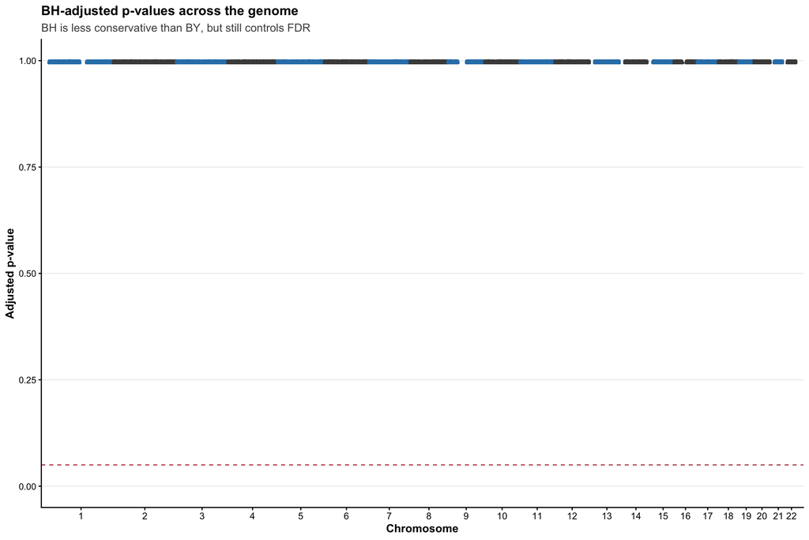

## Benjamini-Krieger-Yekutieli

Now I will try to use the Benjamini-Krieger-Yekutieli method in the `mutoss` package [4]:

Unfortunately, I could not get the `mutoss` package’s implementation of BKY to work, so I will instead follow the original 2006 paper [5], which describes how to implement the BKY method:

```
##    Min. 1st Qu.  Median    Mean 3rd Qu.    Max.
##       1       1       1       1       1       1
```

```
## [1] 0
```

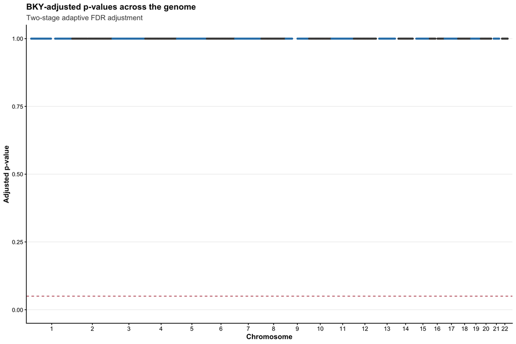

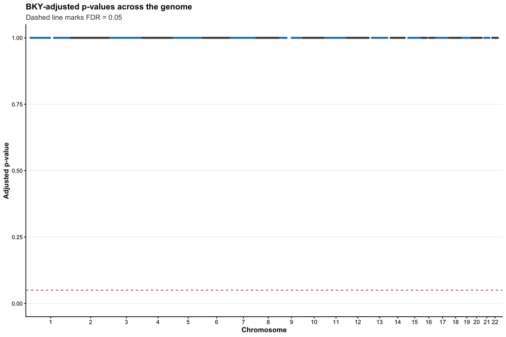

Because BKY estimates the number of true null hypotheses before applying its second-stage threshold, it can be slightly less conservative than the standard BH procedure. In this sample, the important comparison is the number of discoveries, not just whether the adjusted p-values look visually separated on the plot.

## Storey-Tibshirani (q-value)

Now I will be adjusting my p-values using the Storey-Tibshirani method [6]. Thankfully, there is a package in R that was designed in collaboration with the creators of this method, the `qvalue` package. I followed the documentation of the `qvalue` package to use the `qvalue()` method and other methods on my data [7].

```
## [1] 0
```

```
## [1] 0.9885954
```

| Method | Variants below 0.05 |
| --- | --- |
| Benjamini-Yekutieli | 0 |
| Benjamini-Hochberg | 0 |
| Benjamini-Krieger-Yekutieli | 0 |
| Storey-Tibshirani q-value | 0 |

Overall, the different FDR approaches tell a consistent story: after correcting for multiple testing, the 100,000-SNP sample does not provide strong evidence for a large number of robust associations. This does not mean that the original study has no signal. It means that a random subset of the full GWAS is best used here as a method comparison, while definitive association claims should be made from the full dataset.

```
##   #CHROM       POS        ID           P
## 1      6 129950406 rs4254998 1.01288e-05
```

Taking a second look at the smallest raw p-values, there is at least one chromosome 6 candidate worth inspecting because chromosome 6 contains the HLA region, which was important in the original study. I would treat this as an exploratory follow-up rather than a confirmed discovery from this project alone.

Top chromosome 6 candidate in the full chromosome 6 subset:

I used the NCBI Human Genome Data Viewer [8] as a first-pass way to inspect candidate genomic context. The biological interpretation should remain conservative unless the genome build, SNP ID, and nearest-gene annotation are confirmed from the same reference build used in the GWAS summary statistics. If the top chromosome 6 signal maps near immune-related loci, it would be a reasonable candidate for follow-up, but the evidence here is not strong enough to claim a novel immune-response locus.

#Misc graphs

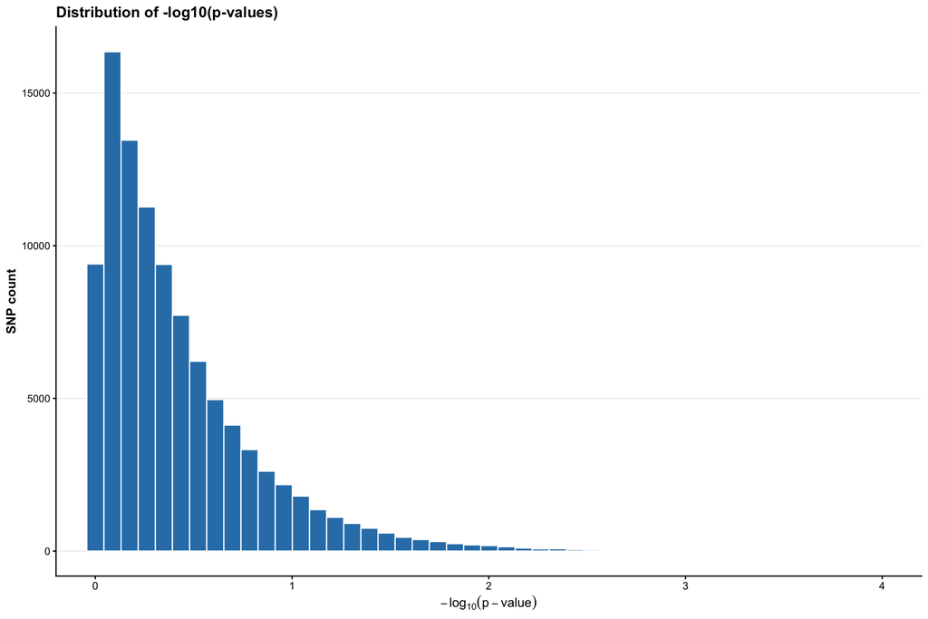

[figure not shown]

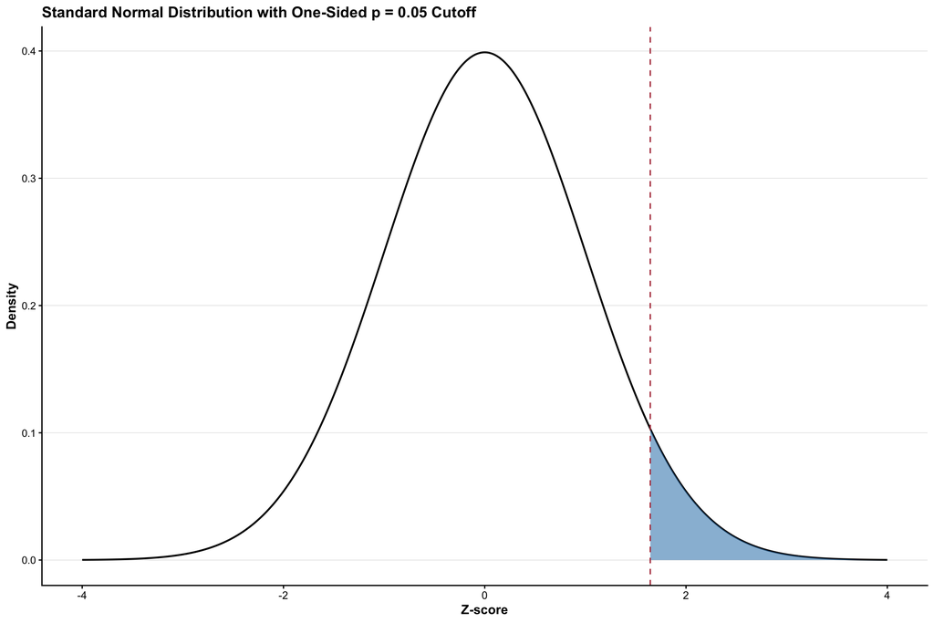

# References

[1] https://www.milieuinterieur.fr/en/about-us/the-milieu-interieur/

[2] Scepanovic, P., Alanio, C., Hammer, C., et al. (2018). Human genetic variants and age are the strongest predictors of humoral immune responses to common pathogens and vaccines. Genome Medicine, 10, 59. https://doi.org/10.1186/s13073-018-0568-8

[3] Wickham, H. (2016). ggplot2: Elegant Graphics for Data Analysis. Springer-Verlag New York. https://ggplot2.tidyverse.org/

[4] https://search.r-project.org/CRAN/refmans/mutoss/html/multiple.down.html

[5] Benjamini, Y., Krieger, A. M., & Yekutieli, D. (2006). Adaptive Linear Step-up Procedures That Control the False Discovery Rate. Biometrika, 93(3), 491–507. https://doi.org/10.1093/biomet/93.3.491

[6] Storey JD, Tibshirani R. Statistical significance for genomewide studies. Proc Natl Acad Sci U S A. 2003 Aug 5;100(16):9440-5. doi: 10.1073/pnas.1530509100. Epub 2003 Jul 25. PMID: 12883005; PMCID: PMC170937.

[7] https://www.rdocumentation.org/packages/qvalue/versions/2.4.2/topics/qvalue

[8] https://www.ncbi.nlm.nih.gov/gdv/